# Red Wine Exploration by QuanHu

从以上分析可以看出，酒精、醋酸、柠檬酸、硫酸盐可以通过散点图、箱线图、密度图等观察到这些特征与质量评分的线性关系。而固定二氧化硫与质量评分的相关系数刚好在上述4个特征之下，其散点图和箱线图与质量评分已经观察不出明显的线性关系，那么剩余的特征应该也更加观察不出和质量评分的线性关系。

接下来将上述4个与质量评分相关关系较好的特征，进行组合来绘制密度图、散点图、箱线图等查看它们是否能对质量评分有更好的区分度。

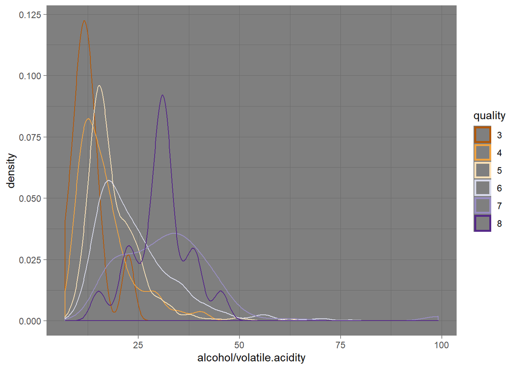

酒精/醋酸的密度图看，好像对于7、8分和3、4、5、6的区分度挺高的。

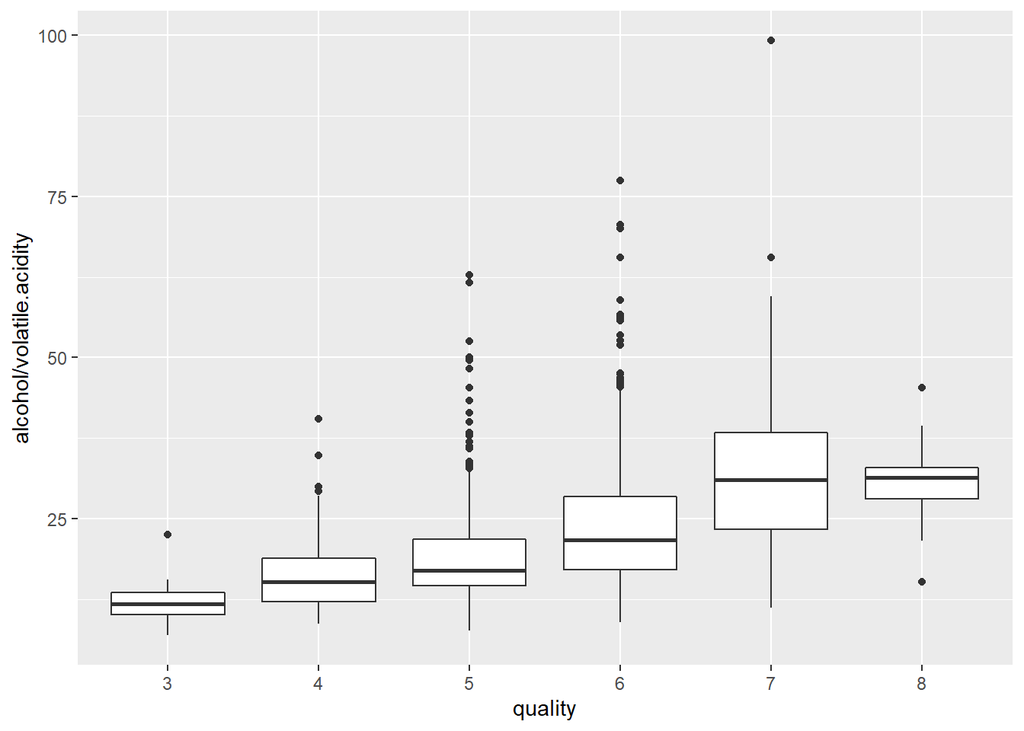

从箱线图也能看出来酒精与醋酸比值和质量评分的线性关系很好，特别是分值较低的时候，特别是3分应该具有很好的区分度。

```
## redwine$quality: 3
##    Min. 1st Qu.  Median    Mean 3rd Qu.    Max.
##   6.899  10.120  11.841  12.517  13.601  22.500
## --------------------------------------------------------
## redwine$quality: 4
##    Min. 1st Qu.  Median    Mean 3rd Qu.    Max.
##   8.673  12.086  15.246  16.608  18.854  40.435
## --------------------------------------------------------
## redwine$quality: 5
##    Min. 1st Qu.  Median    Mean 3rd Qu.    Max.
##   7.661  14.591  16.964  18.783  21.860  62.778
## --------------------------------------------------------
## redwine$quality: 6
##    Min. 1st Qu.  Median    Mean 3rd Qu.    Max.
##    9.00   17.07   21.66   24.12   28.41   77.50
## --------------------------------------------------------
## redwine$quality: 7
##    Min. 1st Qu.  Median    Mean 3rd Qu.    Max.
##   11.15   23.30   31.05   32.15   38.41   99.17
## --------------------------------------------------------
## redwine$quality: 8
##    Min. 1st Qu.  Median    Mean 3rd Qu.    Max.
##   15.18   28.04   31.34   30.60   32.92   45.38
```

从中位数的之来看，酒精/醋酸越大，质量评分应该越高。

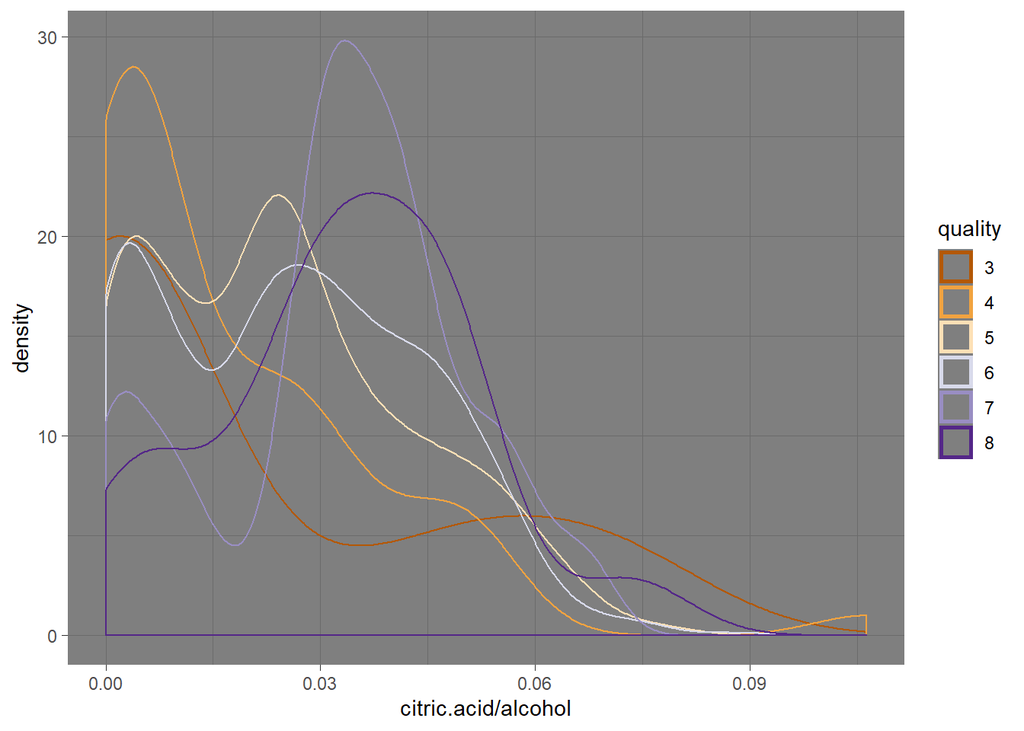

柠檬酸/酒精的密度图和柠檬酸本身的密度图差不多,这两个变量的组合并没有对区分质量评分有更大的帮助。

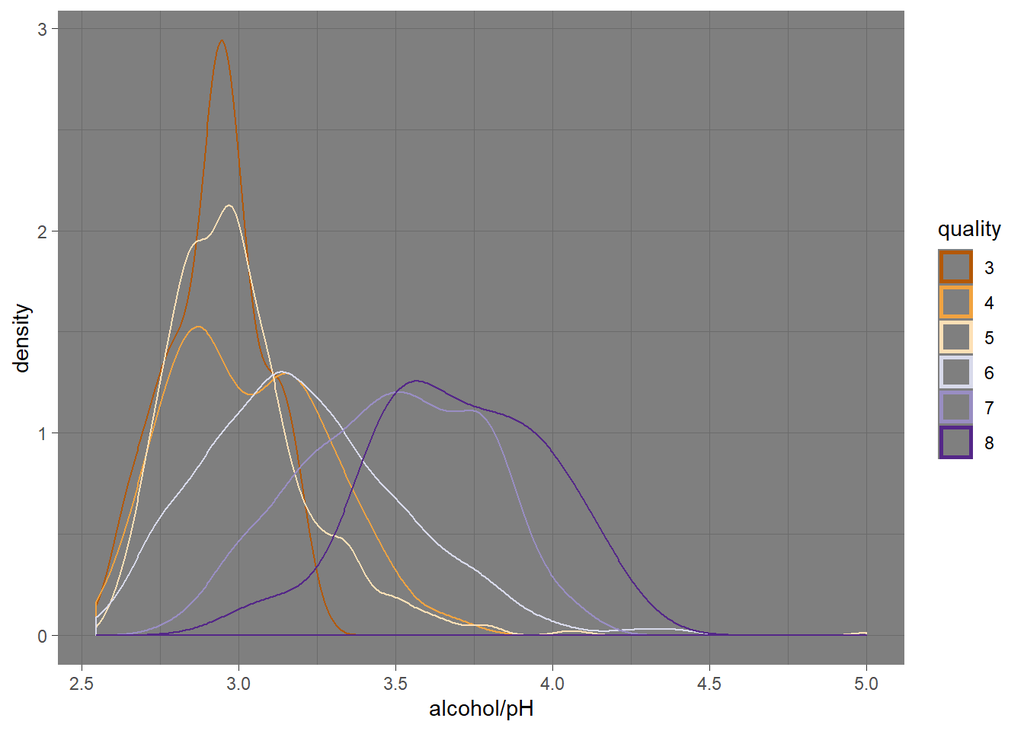

酒精/pH的密度图看出，其可以较好地区分3分和8分的评分，它们密度图重叠区域很少。

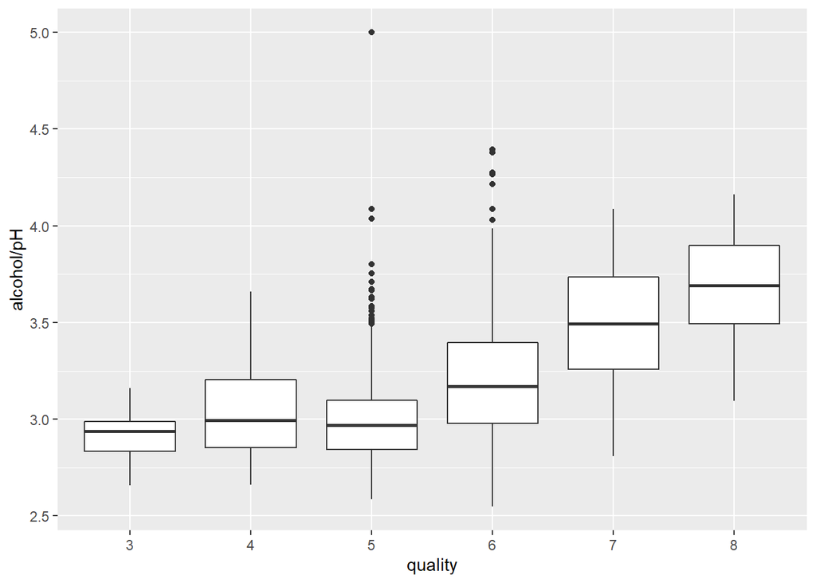

```
## redwine$quality: 3
##    Min. 1st Qu.  Median    Mean 3rd Qu.    Max.
##   2.658   2.834   2.939   2.926   2.988   3.161
## --------------------------------------------------------
## redwine$quality: 4
##    Min. 1st Qu.  Median    Mean 3rd Qu.    Max.
##   2.663   2.853   2.994   3.037   3.206   3.659
## --------------------------------------------------------
## redwine$quality: 5
##    Min. 1st Qu.  Median    Mean 3rd Qu.    Max.
##   2.586   2.844   2.969   2.999   3.098   5.000
## --------------------------------------------------------
## redwine$quality: 6
##    Min. 1st Qu.  Median    Mean 3rd Qu.    Max.
##   2.547   2.978   3.170   3.207   3.396   4.394
## --------------------------------------------------------
## redwine$quality: 7
##    Min. 1st Qu.  Median    Mean 3rd Qu.    Max.
##   2.811   3.257   3.494   3.487   3.735   4.086
## --------------------------------------------------------
## redwine$quality: 8
##    Min. 1st Qu.  Median    Mean 3rd Qu.    Max.
##   3.096   3.494   3.692   3.700   3.899   4.161
```

从描述统计结果来看，也可以得出和箱线图相似的结论，酒精/pH与质量评分有一定的正相关关系，但是对于3-6分的红酒区分不是特别明显，但是对最高评分和最低评分的红酒，它们的酒精/pH特征差距应该是比较大的。

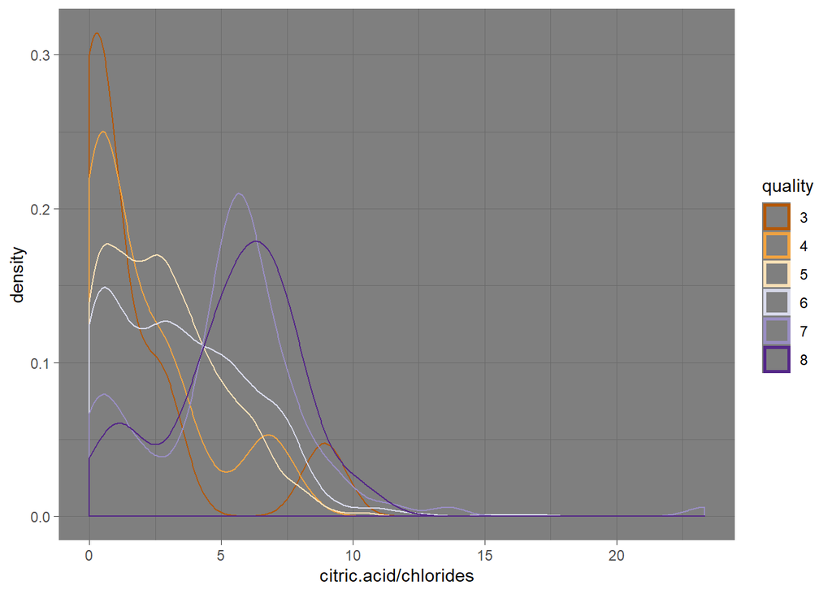

柠檬酸/氯化盐密度图看，其可以很好区分3、4分和7、8分的红酒。

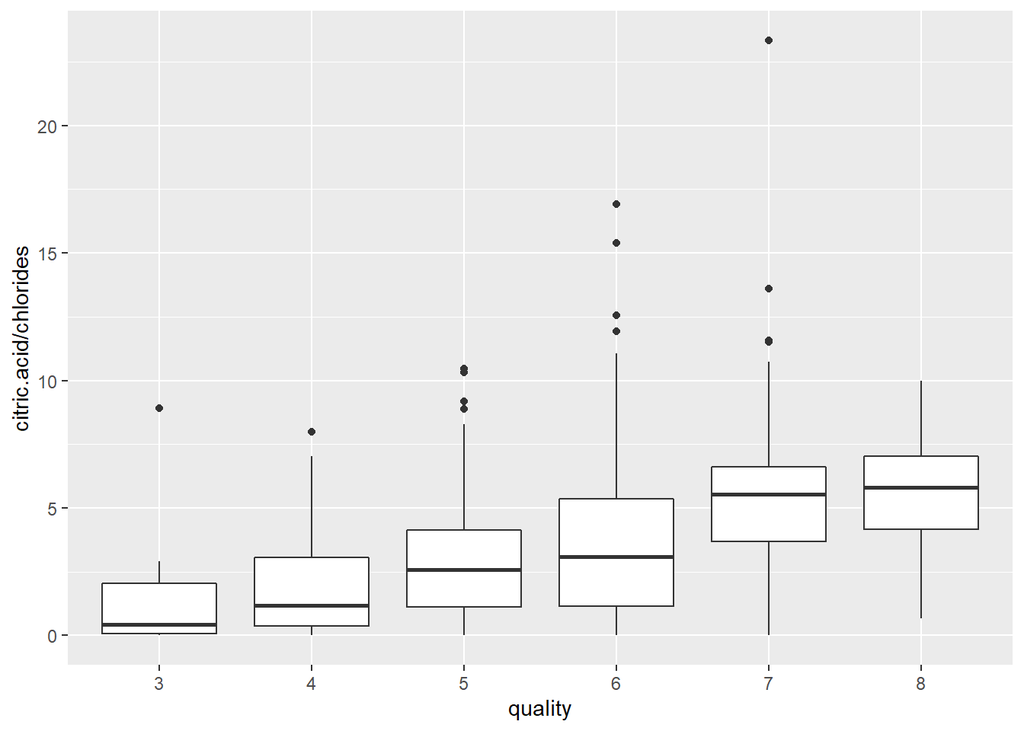

```
## redwine$quality: 3
##    Min. 1st Qu.  Median    Mean 3rd Qu.    Max.
## 0.00000 0.05952 0.43308 1.61894 2.04242 8.91892
## --------------------------------------------------------
## redwine$quality: 4
##    Min. 1st Qu.  Median    Mean 3rd Qu.    Max.
##   0.000   0.375   1.163   2.046   3.068   8.000
## --------------------------------------------------------
## redwine$quality: 5
##    Min. 1st Qu.  Median    Mean 3rd Qu.    Max.
##   0.000   1.111   2.571   2.823   4.125  10.476
## --------------------------------------------------------
## redwine$quality: 6
##    Min. 1st Qu.  Median    Mean 3rd Qu.    Max.
##   0.000   1.134   3.086   3.468   5.366  16.923
## --------------------------------------------------------
## redwine$quality: 7
##    Min. 1st Qu.  Median    Mean 3rd Qu.    Max.
##   0.000   3.693   5.522   5.261   6.603  23.333
## --------------------------------------------------------
## redwine$quality: 8
##    Min. 1st Qu.  Median    Mean 3rd Qu.    Max.
##  0.6818  4.1590  5.8164  5.4405  7.0317 10.0000
```

从中位数看，好像有一定的线性关系，但是三分位数的重叠也很多，可能利用它们对评分进行区分的话效果会不明显。

接下里研究密度和什么特征是相关的，以解答密度大于1的疑惑。

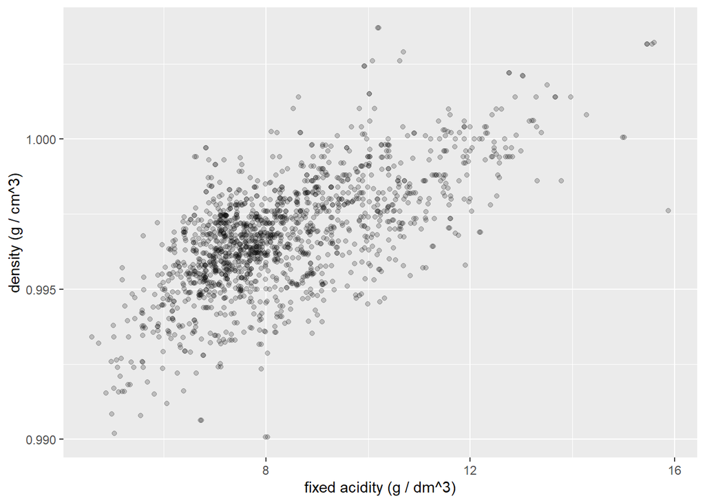

密度和固定酸含量有很强的正相关性，是否是因为固定酸含量较高使得红酒密度上升至大于1，接下来绘制密度大于1的部分红酒数据的密度和固定酸浓度的散点图。

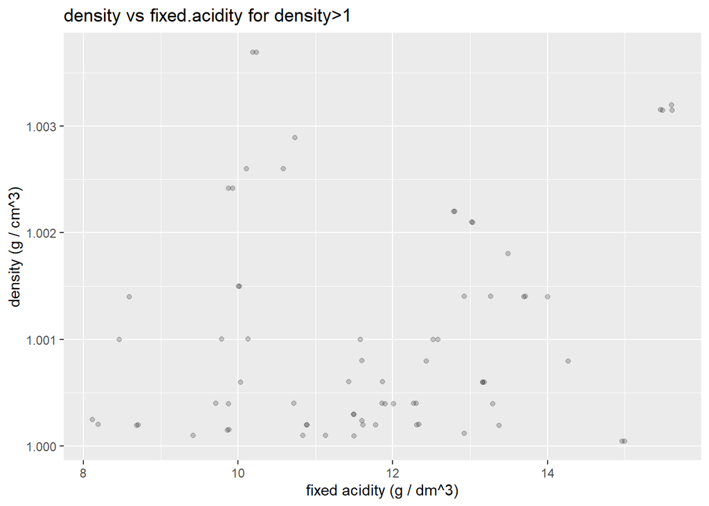

[figure not shown]

从柠檬酸和密度的散点图可以看出，柠檬酸和密度有一定的相关关系，但是相关关系并不如固定酸和密度的相关关系强烈，而且柠檬酸和密度是负相关的关系

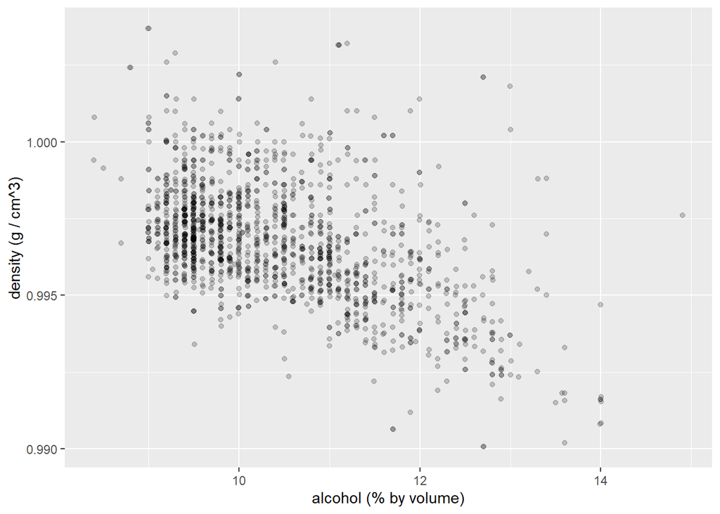

可以看出，酒精含量和密度是反比的关系，毕竟在红酒的成分中酒精的密度是小于1的，酒精越多会把整体密度拉得越低。

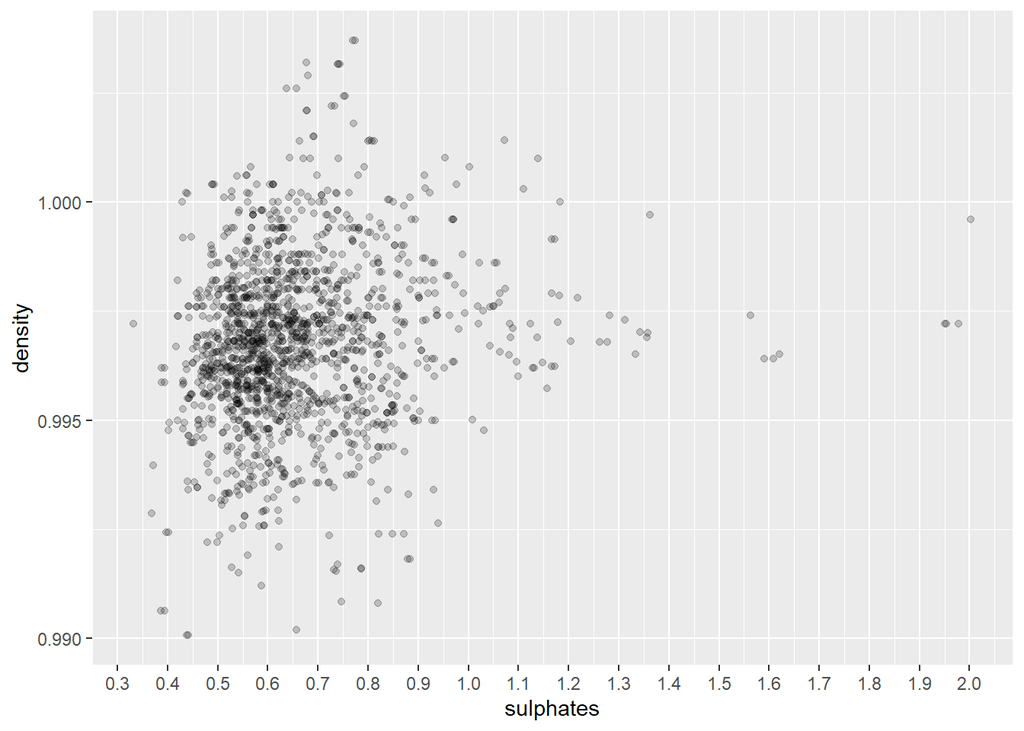

硫酸盐也是红酒中密度大于水的成分，理论上其含量越高红酒的密度也会越大，但实际上硫酸盐和密度并没有太明显的线性关系。

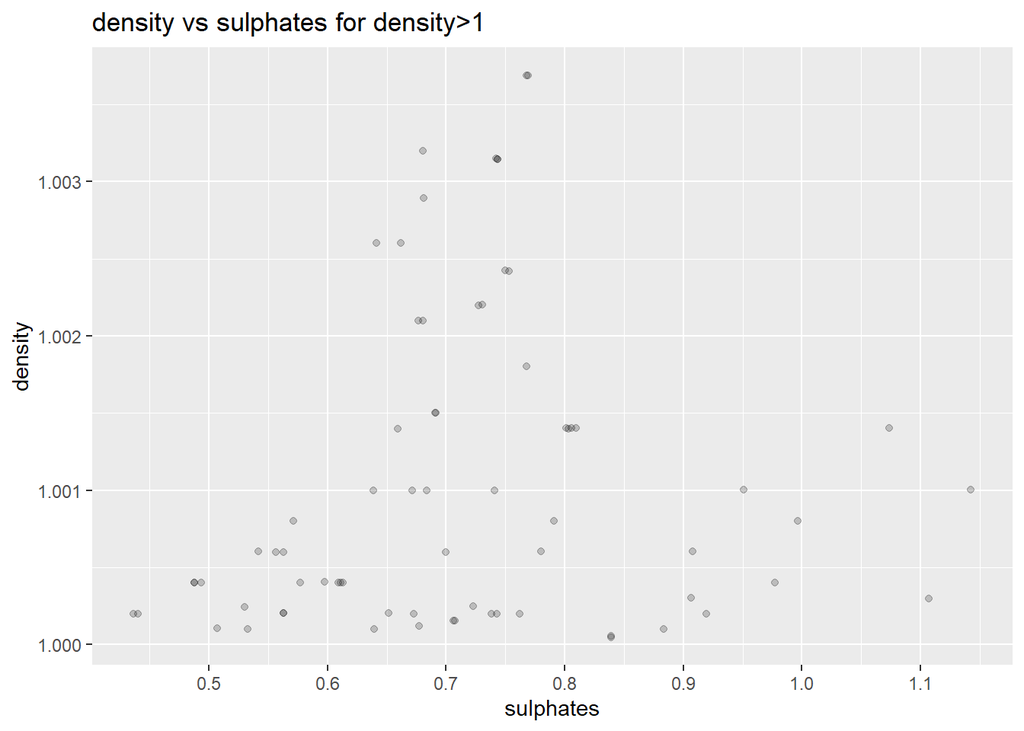

完整数据的硫酸盐的浓度在0.3-2.0之间，而对于密度大于1的红酒其硫酸盐浓度在0.3-1.2之间，可以发现密度高的红酒并没有同时出现硫酸盐含量比较高的特性。说明高密度和硫酸盐没有明显的相关性。

# 双变量分析

### 探讨你在这部分探究中观察到的一些关系。这些感兴趣的特性与数据集内其他特性有什么区别？

**1. 与质量评分的相关性分析**

－ 评分和酒精浓度线性回归预测评分可信度为0.227，通过醋酸含量线性预测评分可信度为0.153。

－ 根据以上分析，酒精浓度和醋酸含量，分别在评分高和低的时候与评分的线性关系较好，猜想或许这两个变量可以很好的预测评分，所以又采用两个变量的组合分析了组合与质量评分的相关关系。

- 酒精/醋酸的密度图看，对于7、8分和3、4、5、6的区分度挺高的。
- 酒精/pH的密度图看出，其可以较好地区分3分和8分的评分，它们密度图重叠区域很少。

**2. 与密度的相关性分析**

- 密度主要和酒精浓度负相关。
- 猜测大于1的红酒，可能是由于固定酸含量高引起，但从目前的分析也的不出确切的结论。

### 你是否观察到主要特性与其他特性之间的有趣关系？

- 质量评分和酒精浓度、醋酸、柠檬酸相关性较高，说明酒精浓度、醋酸、柠檬酸含量会比较明显地影响红酒的口感。
- 从密度和其他变量的相关性来看，密度主要由酒精和固定酸决定，酒精含量增加会拉低红酒密度，固定酸含量增加会拉高红酒密度。

### 你发现最强的关系是什么？

- 固定二氧化硫含量和总二氧化硫含量的线性关系很强烈。
- 固定酸含量和柠檬酸含量的线性关系也比较明显。

# 多变量绘图选择

通过前文的分析，我们知道与质量评分相关关系最好的两个特征是酒精与醋酸，那么我们以酒精与醋酸绘制散点图，并以不同颜色标注质量评分不同的点，如下：

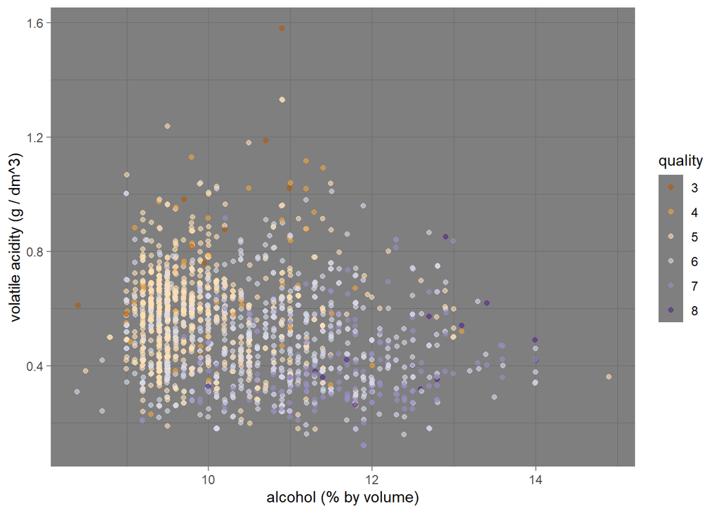

好像并不能很好地区分不同的分数，但是也能看出来随着酒精浓度上升评分在逐渐升高，随着醋酸浓度上升评分在降低。我们看看这两个特征是否能区分评分的最高分和最低分。

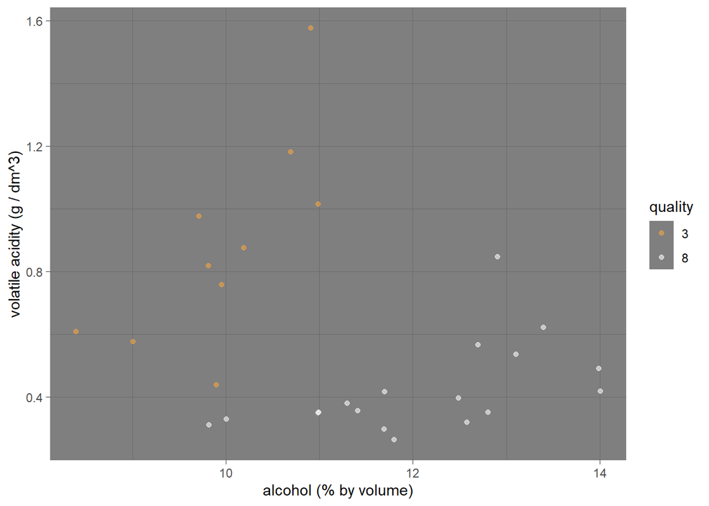

如果只绘制最高分和最低分，酒精浓度和醋酸含量的散点图中，可以通过一条直线将最高分和最低分区分开。

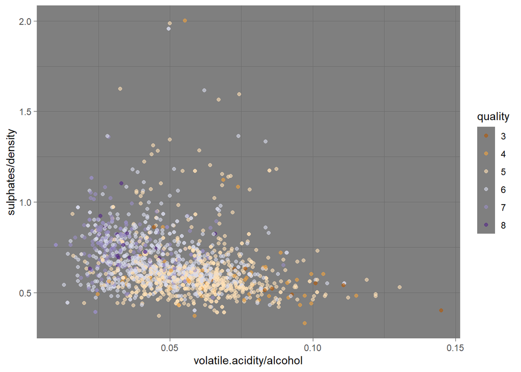

尝试绘制一个散点图，来查看硫酸盐/密度、醋酸/酒精是否能对质量评分进行一定程度的区分，发现上述四个特征并不能很好的区分质量评分。但是能看出3-4分的点更集中在右下角，7-8分的点更集中在左上角。

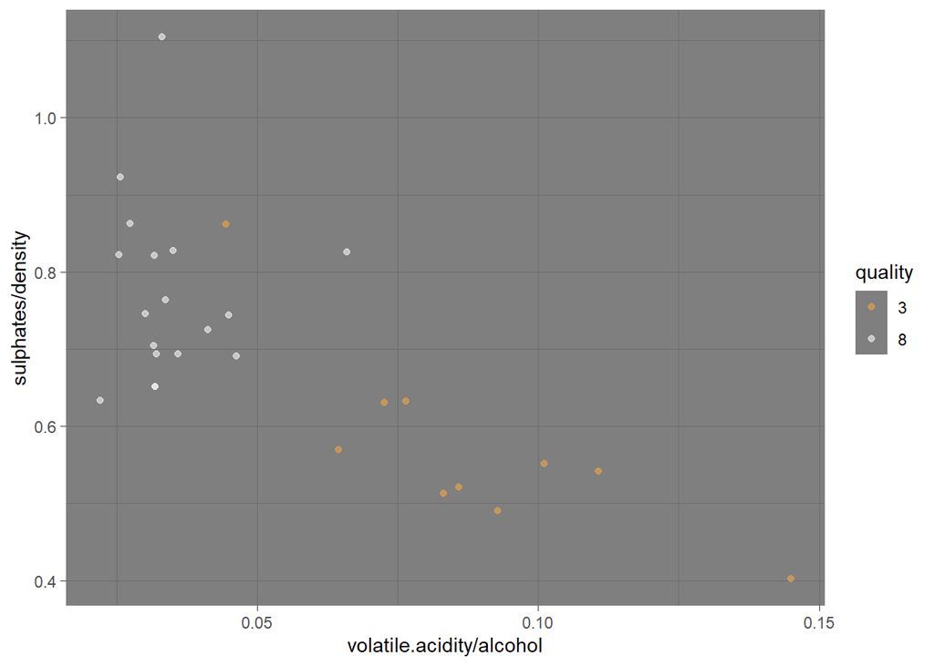

通过只绘制最高评分和最低评分的散点图，发现硫酸盐/密度、醋酸/酒精这四个特征可以很好的区分最高分和最低分，而且是两条与x轴和y轴平行的线就可以将3分和8分区分开来。

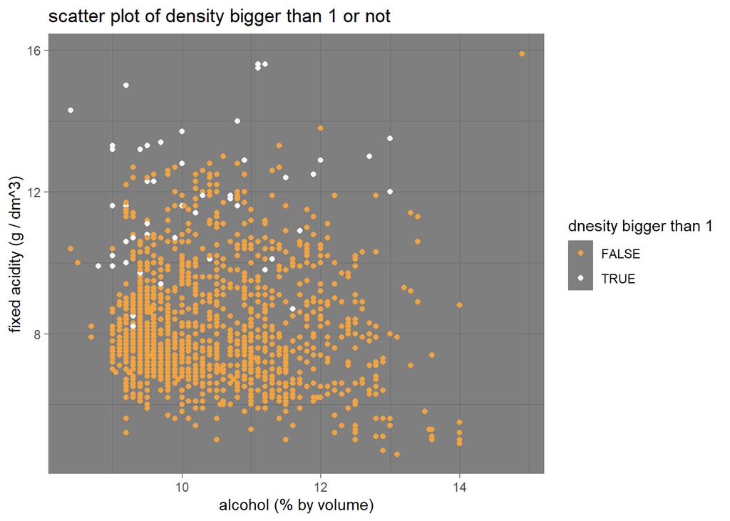

密度方面，通过之前分析的酒精和固定酸可以比较好的区分密度是否大于1，但是从散点图来看，区分度并不是很明显。

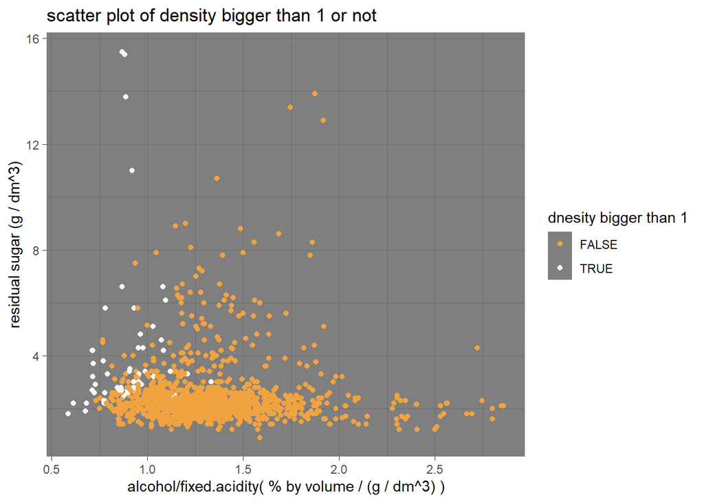

对于密度的区分做了更多绘制散点图的尝试，当横轴为酒精/固定酸，纵轴为残余糖时，得到的散点图可以相对更好地区分出密度是否大于1。

接下来对于预测质量评分，尝试建立线性模型进行预测：

```
##
## Calls:
## m1: lm(formula = quality ~ alcohol, data = redwine)
## m2: lm(formula = quality ~ alcohol + volatile.acidity, data = redwine)
## m3: lm(formula = quality ~ alcohol + volatile.acidity + sulphates,
##     data = redwine)
## m4: lm(formula = quality ~ alcohol + volatile.acidity + sulphates +
##     fixed.acidity, data = redwine)
## m5: lm(formula = quality ~ alcohol + volatile.acidity + sulphates +
##     fixed.acidity + citric.acid, data = redwine)
## m6: lm(formula = quality ~ alcohol + volatile.acidity + sulphates +
##     fixed.acidity + citric.acid + chlorides, data = redwine)
## m7: lm(formula = quality ~ alcohol + volatile.acidity + sulphates +
##     fixed.acidity + citric.acid + chlorides + total.sulfur.dioxide,
##     data = redwine)
##
## ===================================================================================================================
##                             m1           m2           m3           m4           m5           m6           m7
## -------------------------------------------------------------------------------------------------------------------
##   (Intercept)              3.875***     5.095***     4.611***     4.313***     4.202***     4.363***     4.652***
##                           (0.175)      (0.184)      (0.196)      (0.223)      (0.224)      (0.228)      (0.240)
##   alcohol                  0.361***     0.314***     0.309***     0.315***     0.320***     0.304***     0.288***
##                           (0.017)      (0.016)      (0.016)      (0.016)      (0.016)      (0.017)      (0.017)
##   volatile.acidity                     -1.384***    -1.221***    -1.155***    -1.343***    -1.239***    -1.173***
##                                        (0.095)      (0.097)      (0.100)      (0.113)      (0.117)      (0.118)
##   sulphates                                          0.679***     0.642***     0.701***     0.851***     0.888***
##                                                     (0.101)      (0.101)      (0.103)      (0.111)      (0.111)
##   fixed.acidity                                                   0.028**      0.057***     0.050***     0.037**
##                                                                  (0.010)      (0.013)      (0.013)      (0.014)
##   citric.acid                                                                 -0.469***    -0.335*      -0.203
##                                                                               (0.137)      (0.141)      (0.145)
##   chlorides                                                                                -1.430***    -1.576***
##                                                                                            (0.408)      (0.408)
##   total.sulfur.dioxide                                                                                  -0.002***
##                                                                                                         (0.001)
## -------------------------------------------------------------------------------------------------------------------
##   R-squared                0.227        0.317        0.336        0.339        0.344        0.349        0.355
##   N                     1599         1599         1599         1599         1599         1599         1599
## ===================================================================================================================
##   Significance: *** = p < 0.001; ** = p < 0.01; * = p < 0.05
```

尝试建立线性模型对红酒的评分进行预测，发现使用7个变量也不能得到很好的决定系数，

# 多变量分析

### 探讨你在这部分探究中观察到的一些关系。通过观察感兴趣的特性，是否存在相互促进的特性？

- 如果只绘制最高分和最低分，酒精浓度和醋酸含量的散点图中，可以通过一条直线将最高分和最低分区分开。
- 如果散点图使用4个特征醋酸、酒精、硫酸盐和密度，则可以通过平行于x轴和y轴的两条线，将最高分和最低分几乎完全正确地区分开。
- 创建了密度是否大于1的数据。从最后两幅图看，酒精和固定酸能区分部分红酒密度是否大于1，加入残余糖特征可以使密度是否大于1在散点图中区分度更好。

### 这些特性之间是否存在有趣或惊人的联系呢？

- 发现红酒密度不仅仅和酒精浓度关系较密切，而且和残余糖有比较大的关系，通过散点图可以看出，只要酒精浓度、固定酸加入残余糖就可以更好地区分密度是否大于1。
- 发现分数的集中段5-6分所有特征都不能很好区分，但是如果只考察3分和8分，使用4个特征醋酸、酒精、硫酸盐和密度这四个特征可以几乎完全正确地将3分和8分的红酒区分开。

### 选项：你是否创建过数据集的任何模型？讨论你模型的优缺点。

尝试使用了线性模型来预测红酒的质量评分，发现并不能高准确率的预测红酒评分，估计可能使由于质量评分只有3-8分的6个离散值，而线性模型是预测连续数据的模型，如果使用分类模型可能能较好地预测质量评分。

# 定稿图与总结

### 绘图一

[figure not shown]

### 绘图二

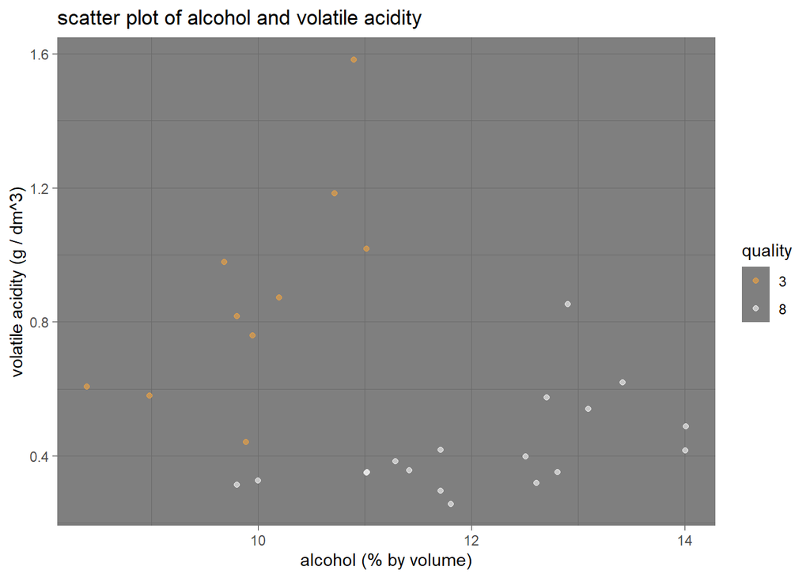

### 绘图三

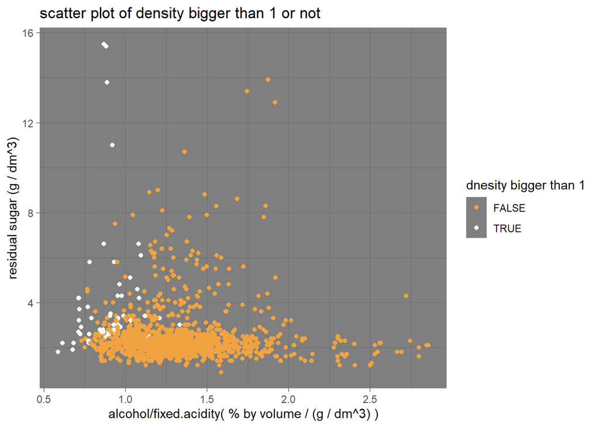

### 描述三

从上述散点图可以看出，酒精、固定酸和残余糖这三个特征可以获得密度是否大于1较好的区分度。

# 反思

红酒数据集包含对1599个不同红酒的观察，每一个观察对象包含12个特征。本文的分析，主要基于这12个特征及基于它们新建的特征，尝试通过特征预测红酒的质量评分，及分析部分红酒密度大于1的主要因素。

接下来的双变量分析，重点分析了质量评分和密度与哪些特征相关。我们发现质量评分与红酒中的酒精浓度存在一定的正相关关系，说明酒精浓度高的红酒更容易获得高评分，而醋酸与红酒质量评分负相关，可能偏酸的口感会拉低红酒的评分。而密度方面，密度和酒精浓度负相关，和固定酸含量正相关，而且密度大于1的红酒的固定酸浓度大体上分布在较高的区域，说明密度大于1可能是因为太大的固定酸含量使红酒密度上升。

最后的多变量分析中，我们尝试使用多个变量绘制散点图的方式将不同评分的红酒在散点图中分开，但是5-6分的红酒过于集中，使用数据集中的特征没有明显将它们分开。而如果我们使用醋酸和酒精这两个特征，绘制的最高分和最低分的散点图，则可以通过一条直线将3分和8分的红酒区分开，再进一步尝试中，我们加入更大特征绘制散点图，我们使用4个特征醋酸、酒精、硫酸盐和密度，区分3分和8分的红酒并没有比仅仅醋酸和酒精表现出更好的效果。我们也尝试使用酒精、醋酸和其他特征建立线性模型预测红酒评分，但是建立的模型的决定系数都小于0.5，说明模型不够反映实际情况，或者可能是特征不够不能重复预测质量评分，这里我想如果有红酒的价格和体积数据可能会对预测质量评分有些帮助。而密度方面，双变量分析时发现酒精和固定酸能区分部分红酒密度是否大于1，这里加入了残余糖绘制的散点图看出，或许酒精、固定酸、残余糖这三个变量才能更好地区分红酒密度是否大于1。

数据来源：

[1] P. Cortez, A. Cerdeira, F. Almeida et al. Modeling wine preferences by data mining from physicochemical properties. Decision Support Systems, Elsevier, 47(4):547-553. ISSN: 0167-9236.